# Classification of pengiuns from the Palmer Archipelago

The dataset was foundd on kaggle:https://www.kaggle.com/datasets/parulpandey/palmer-archipelago-antarctica-penguin-data

The columns are:

- Species
- island
- culmen length
- culmen depth
- flipper length
- body mass

The culmen is "the upper ridge of a bird's beak" (definition from Oxford Languages).

Lets start by importing our libraries we will be using

```python
import pandas as pd
import numpy as np
import matplotlib.pyplot as plt
import seaborn as sns
```

Now we will read our csv file

```python
df=pd.read_csv("penguins_size.csv")
```

Lets take a Quick look at our first 5 entries

```python
df.head()
```

|  | species | island | culmen_length_mm | culmen_depth_mm | flipper_length_mm | body_mass_g | sex |
| --- | --- | --- | --- | --- | --- | --- | --- |
| 0 | Adelie | Torgersen | 39.1 | 18.7 | 181.0 | 3750.0 | MALE |
| 1 | Adelie | Torgersen | 39.5 | 17.4 | 186.0 | 3800.0 | FEMALE |
| 2 | Adelie | Torgersen | 40.3 | 18.0 | 195.0 | 3250.0 | FEMALE |
| 3 | Adelie | Torgersen | NaN | NaN | NaN | NaN | NaN |
| 4 | Adelie | Torgersen | 36.7 | 19.3 | 193.0 | 3450.0 | FEMALE |

Noticing that our 4th entry contains empty values using the interpolate method which help us fill those nan values

```python
df = df.interpolate(method='linear')
```

```python
df.head()
```

|  | species | island | culmen_length_mm | culmen_depth_mm | flipper_length_mm | body_mass_g | sex |
| --- | --- | --- | --- | --- | --- | --- | --- |
| 0 | Adelie | Torgersen | 39.1 | 18.70 | 181.0 | 3750.0 | MALE |
| 1 | Adelie | Torgersen | 39.5 | 17.40 | 186.0 | 3800.0 | FEMALE |
| 2 | Adelie | Torgersen | 40.3 | 18.00 | 195.0 | 3250.0 | FEMALE |
| 3 | Adelie | Torgersen | 38.5 | 18.65 | 194.0 | 3350.0 | NaN |
| 4 | Adelie | Torgersen | 36.7 | 19.30 | 193.0 | 3450.0 | FEMALE |

That worked other then the sex column but I feel the sex column will not help with this project so we will just drop that column

```python
df=df.drop(columns= ['sex'])
```

```python
df.head()
```

|  | species | island | culmen_length_mm | culmen_depth_mm | flipper_length_mm | body_mass_g |
| --- | --- | --- | --- | --- | --- | --- |
| 0 | Adelie | Torgersen | 39.1 | 18.70 | 181.0 | 3750.0 |
| 1 | Adelie | Torgersen | 39.5 | 17.40 | 186.0 | 3800.0 |
| 2 | Adelie | Torgersen | 40.3 | 18.00 | 195.0 | 3250.0 |
| 3 | Adelie | Torgersen | 38.5 | 18.65 | 194.0 | 3350.0 |
| 4 | Adelie | Torgersen | 36.7 | 19.30 | 193.0 | 3450.0 |

Now that are data is ready lets look at some visualizations

# Visualizations

Lets take a look at our island column

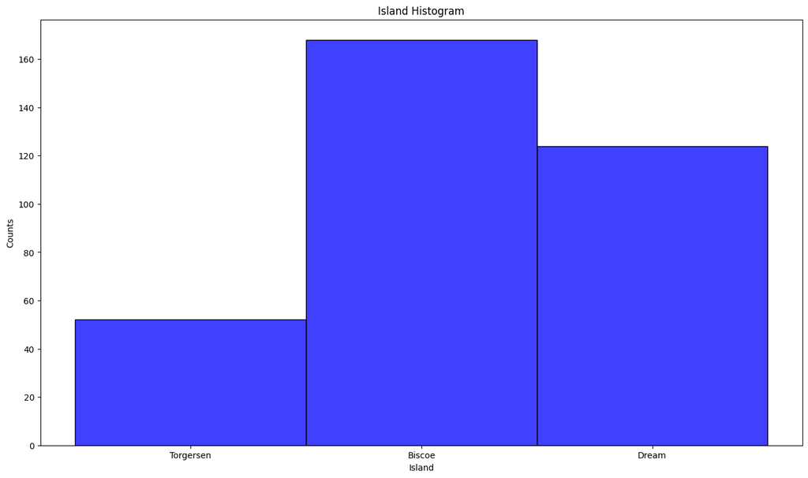

```python
plt.figure(figsize=(16,9))
sns.histplot(df['island'],color='Blue')
plt.title("Island Histogram")
plt.ylabel("Counts")
plt.xlabel("Island")
plt.show()
```

Nothing horribly skewed just a big outlier but nothing skewed left or right. Lets take a lot at species.

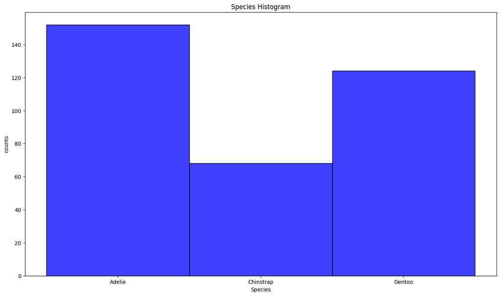

```python
plt.figure(figsize=(16,9))
sns.histplot(df['species'],color='Blue')
plt.title("Species Histogram")
plt.ylabel("counts")
plt.xlabel("Species")
plt.show()
```

Seems the chinstraps didnt get observed much but nonetheless seem a bit skewed. Finally lets look at the rest of thje ddata comparedd to the species.

[output not shown]

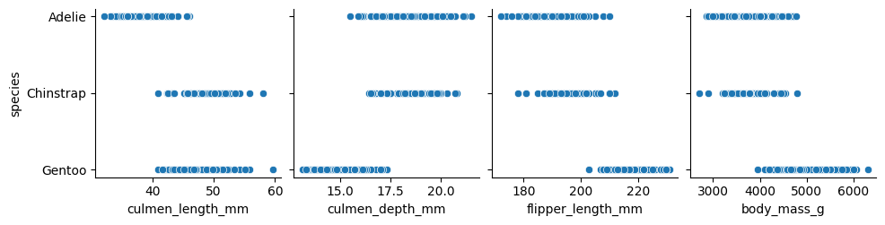

```python
sns.pairplot(data=df,y_vars='species',kind='scatter')
```

Refrences Dataset: https://www.kaggle.com/datasets/parulpandey/palmer-archipelago-antarctica-penguin-data

Interpolate method: https://www.geeksforgeeks.org/python-pandas-dataframe-interpolate/